# Lab Assignment One: Exploring Table Data

## 1. Business Understanding

Cars play an irreplaceable role in our daliy life. There are astronomically vehicle transcations happen every day. Most of them are used car transactions. In these transactions,price has always been an important issue for buyers and sellers beacuse buyers want to buy the best car at the lowest price and sellers want to sale the worst cars at the best price.

Through visualizing the features, exploring the features relationships, and other methods, we are able to help buyers to know the influence of differet factors on price of used cars and able to help sellers know the correlation between price,gearbox,brand,fueltype,powerPS and other features.

From the analyzing, the buyers could have an idea what is the bset car thay can buy under their budget. In addition, the seller could make a decision that whether they could buy the car to achieve the profit maximization.

Overall, the analytics also aid buyers and sellers to predict the price of car according to different features they got.

========================================================================

Dataset: Uesd cars database URL: https://www.kaggle.com/orgesleka/used-cars-database

Question Of Interest: Which features are the main factors for determing price for used cars?

## 2. Data Understanding

### 2.1 Data Description

```python
# load the used car dataset
import pandas as pd
import numpy as np
import seaborn as sns;
import warnings
warnings.filterwarnings("ignore")
sns.set(style = 'white', color_codes=True)
df = pd.read_csv('autos.csv',encoding='latin_1')
df.head()
```

|  | dateCrawled | name | seller | offerType | price | abtest | vehicleType | yearOfRegistration | gearbox | powerPS | model | kilometer | monthOfRegistration | fuelType | brand | notRepairedDamage | dateCreated | nrOfPictures | postalCode | lastSeen |
| --- | --- | --- | --- | --- | --- | --- | --- | --- | --- | --- | --- | --- | --- | --- | --- | --- | --- | --- | --- | --- |
| 0 | 2016-03-24 11:52:17 | Golf_3_1.6 | privat | Angebot | 480 | test | NaN | 1993 | manuell | 0 | golf | 150000 | 0 | benzin | volkswagen | NaN | 2016-03-24 00:00:00 | 0 | 70435 | 2016-04-07 03:16:57 |
| 1 | 2016-03-24 10:58:45 | A5_Sportback_2.7_Tdi | privat | Angebot | 18300 | test | coupe | 2011 | manuell | 190 | NaN | 125000 | 5 | diesel | audi | ja | 2016-03-24 00:00:00 | 0 | 66954 | 2016-04-07 01:46:50 |
| 2 | 2016-03-14 12:52:21 | Jeep_Grand_Cherokee_"Overland" | privat | Angebot | 9800 | test | suv | 2004 | automatik | 163 | grand | 125000 | 8 | diesel | jeep | NaN | 2016-03-14 00:00:00 | 0 | 90480 | 2016-04-05 12:47:46 |
| 3 | 2016-03-17 16:54:04 | GOLF_4_1_4__3TÜRER | privat | Angebot | 1500 | test | kleinwagen | 2001 | manuell | 75 | golf | 150000 | 6 | benzin | volkswagen | nein | 2016-03-17 00:00:00 | 0 | 91074 | 2016-03-17 17:40:17 |
| 4 | 2016-03-31 17:25:20 | Skoda_Fabia_1.4_TDI_PD_Classic | privat | Angebot | 3600 | test | kleinwagen | 2008 | manuell | 69 | fabia | 90000 | 7 | diesel | skoda | nein | 2016-03-31 00:00:00 | 0 | 60437 | 2016-04-06 10:17:21 |

```python
df.info()
```

```
<class 'pandas.core.frame.DataFrame'>
RangeIndex: 371528 entries, 0 to 371527
Data columns (total 20 columns):
dateCrawled            371528 non-null object
name                   371528 non-null object
seller                 371528 non-null object
offerType              371528 non-null object
price                  371528 non-null int64
abtest                 371528 non-null object
vehicleType            333659 non-null object
yearOfRegistration     371528 non-null int64
gearbox                351319 non-null object
powerPS                371528 non-null int64
model                  351044 non-null object
kilometer              371528 non-null int64
monthOfRegistration    371528 non-null int64
fuelType               338142 non-null object
brand                  371528 non-null object
notRepairedDamage      299468 non-null object
dateCreated            371528 non-null object
nrOfPictures           371528 non-null int64
postalCode             371528 non-null int64
lastSeen               371528 non-null object
dtypes: int64(7), object(13)
memory usage: 56.7+ MB
```

```python
df.describe()
```

|  | price | yearOfRegistration | powerPS | kilometer | monthOfRegistration | nrOfPictures | postalCode |
| --- | --- | --- | --- | --- | --- | --- | --- |
| count | 3.715280e+05 | 371528.000000 | 371528.000000 | 371528.000000 | 371528.000000 | 371528.0 | 371528.00000 |
| mean | 1.729514e+04 | 2004.577997 | 115.549477 | 125618.688228 | 5.734445 | 0.0 | 50820.66764 |
| std | 3.587954e+06 | 92.866598 | 192.139578 | 40112.337051 | 3.712412 | 0.0 | 25799.08247 |
| min | 0.000000e+00 | 1000.000000 | 0.000000 | 5000.000000 | 0.000000 | 0.0 | 1067.00000 |
| 25% | 1.150000e+03 | 1999.000000 | 70.000000 | 125000.000000 | 3.000000 | 0.0 | 30459.00000 |
| 50% | 2.950000e+03 | 2003.000000 | 105.000000 | 150000.000000 | 6.000000 | 0.0 | 49610.00000 |
| 75% | 7.200000e+03 | 2008.000000 | 150.000000 | 150000.000000 | 9.000000 | 0.0 | 71546.00000 |
| max | 2.147484e+09 | 9999.000000 | 20000.000000 | 150000.000000 | 12.000000 | 0.0 | 99998.00000 |

### 2.2 Data Quality

#### 2.2.1 Cleaning Empty Data and Convert Date

```python
#explain a little bit why these columns are not useful
#drop columns not in use
df.drop(['dateCrawled', 'monthOfRegistration', 'dateCreated',
                   'lastSeen','seller','offerType','abtest','nrOfPictures'], axis=1, inplace=True)
```

```python
# Clean data with empty value in model, price, gearbox or fuelType or vehicleType
df = df[(df['model'].notnull()) & (df['price'].notnull()) & (df['gearbox'].notnull()) & (df['fuelType'].notnull() & (df['vehicleType'].notnull()))]
```

There has a chance that two instances in the information are the same, then we have to consider whether we have to drop duplicates. Two instances are the same means the two cars have same name, year of registration, brand, model, postal code, etc, and also have the same price, we think it is possible. So we won't drop dulicate data.

```python
df.info()
```

```
<class 'pandas.core.frame.DataFrame'>
Int64Index: 299864 entries, 2 to 371527
Data columns (total 12 columns):
name                  299864 non-null object
price                 299864 non-null int64
vehicleType           299864 non-null object
yearOfRegistration    299864 non-null int64
gearbox               299864 non-null object
powerPS               299864 non-null int64
model                 299864 non-null object
kilometer             299864 non-null int64
fuelType              299864 non-null object
brand                 299864 non-null object
notRepairedDamage     260956 non-null object
postalCode            299864 non-null int64
dtypes: int64(5), object(7)
memory usage: 29.7+ MB
```

```python
#default all records without value in notRepairedDamage to True
df['notRepairedDamage'].fillna('ja', inplace=True)
```

```python
#replace value in notRepairedDamage to True and False
df['notRepairedDamage'].replace(['ja', 'nein'], [True, False], inplace=True)
```

```python
df.head()
```

|  | name | price | vehicleType | yearOfRegistration | gearbox | powerPS | model | kilometer | fuelType | brand | notRepairedDamage | postalCode |
| --- | --- | --- | --- | --- | --- | --- | --- | --- | --- | --- | --- | --- |
| 2 | Jeep_Grand_Cherokee_"Overland" | 9800 | suv | 2004 | automatik | 163 | grand | 125000 | diesel | jeep | True | 90480 |
| 3 | GOLF_4_1_4__3TÜRER | 1500 | kleinwagen | 2001 | manuell | 75 | golf | 150000 | benzin | volkswagen | False | 91074 |
| 4 | Skoda_Fabia_1.4_TDI_PD_Classic | 3600 | kleinwagen | 2008 | manuell | 69 | fabia | 90000 | diesel | skoda | False | 60437 |
| 5 | BMW_316i___e36_Limousine___Bastlerfahrzeug__Ex... | 650 | limousine | 1995 | manuell | 102 | 3er | 150000 | benzin | bmw | True | 33775 |
| 6 | Peugeot_206_CC_110_Platinum | 2200 | cabrio | 2004 | manuell | 109 | 2_reihe | 150000 | benzin | peugeot | False | 67112 |

```python
#check null values in the dataframe
df.isnull().sum()
```

```
name                  0
price                 0
vehicleType           0
yearOfRegistration    0
gearbox               0
powerPS               0
model                 0
kilometer             0
fuelType              0
brand                 0
notRepairedDamage     0
postalCode            0
dtype: int64
```

#### 2.2.2 Cleaning Useless Data

```python
# Only analyze cars registered between 1980 and 2017
print("Too old: {}".format(df.loc[df.yearOfRegistration < 1980].count()['price']))
print("Too new: {}".format(df.loc[df.yearOfRegistration >= 2018].count()['price']))
print("Too cheap: %d" % df.loc[df.price < 100].count()['name'])
print("Too expensive: " , df.loc[df.price > 150000].count()['name'])
print("Too few PS: " , df.loc[df.powerPS < 50].count()['name'])
print("Too many PS: " , df.loc[df.powerPS > 500].count()['name'])
##print("{} percent of the entire dataset is remained for analyze after Year of Registration Cleaning".format(df['price'].count() / old_df['price'].count() * 100))
```

```
Too old: 2395
Too new: 3
Too cheap: 5987
Too expensive:  119
Too few PS:  20525
Too many PS:  584
```

```python
df = df[(df.yearOfRegistration >= 1980)&(df.yearOfRegistration <= 2017)
        & (df.price >= 100) & (df.price <= 150000)
        & (df.powerPS > 50) & (df.powerPS <= 800)]
```

```python
#change dtype of kilometer from object to int
df['kilometer'] = df['kilometer'].apply(pd.to_numeric)
```

```python
df.info()
```

```
<class 'pandas.core.frame.DataFrame'>
Int64Index: 269272 entries, 2 to 371527
Data columns (total 12 columns):
name                  269272 non-null object
price                 269272 non-null int64
vehicleType           269272 non-null object
yearOfRegistration    269272 non-null int64
gearbox               269272 non-null object
powerPS               269272 non-null int64
model                 269272 non-null object
kilometer             269272 non-null int64
fuelType              269272 non-null object
brand                 269272 non-null object
notRepairedDamage     269272 non-null bool
postalCode            269272 non-null int64
dtypes: bool(1), int64(5), object(6)
memory usage: 24.9+ MB
```

```python
df.describe()
```

|  | price | yearOfRegistration | powerPS | kilometer | postalCode |
| --- | --- | --- | --- | --- | --- |
| count | 269272.000000 | 269272.000000 | 269272.000000 | 269272.000000 | 269272.000000 |
| mean | 6596.580421 | 2003.579830 | 130.191539 | 124922.216198 | 51956.230258 |
| std | 8064.872754 | 5.783108 | 60.687106 | 39314.263100 | 25784.946428 |
| min | 100.000000 | 1980.000000 | 51.000000 | 5000.000000 | 1067.000000 |
| 25% | 1600.000000 | 2000.000000 | 88.000000 | 100000.000000 | 31535.000000 |
| 50% | 3900.000000 | 2004.000000 | 116.000000 | 150000.000000 | 51109.000000 |
| 75% | 8500.000000 | 2008.000000 | 156.000000 | 150000.000000 | 72793.000000 |
| max | 150000.000000 | 2017.000000 | 776.000000 | 150000.000000 | 99998.000000 |

```python
ddf = df.copy()

branddic = pd.Series(range(39),index=ddf.brand.unique()).to_dict()
vtdic = pd.Series(range(8),index=ddf.vehicleType.unique()).to_dict()
geardic = pd.Series(range(2),index=ddf.gearbox.unique()).to_dict()
fueldic = pd.Series(range(7),index=ddf.fuelType.unique()).to_dict()
modeldic = pd.Series(range(248),index=ddf.model.unique()).to_dict()
nrddic = pd.Series(range(2),index=ddf.notRepairedDamage.unique()).to_dict()

ddf['brand'] = ddf['brand'].map(branddic)
ddf['vehicleType'] = ddf['vehicleType'].map(vtdic)
ddf['gearbox'] = ddf['gearbox'].map(geardic)
ddf['fuelType'] = ddf['fuelType'].map(fueldic)
ddf['model'] = ddf['model'].map(modeldic)
ddf['notRepairedDamage'] = ddf['notRepairedDamage'].map(nrddic)
```

```python
ddf.head()
```

|  | name | price | vehicleType | yearOfRegistration | gearbox | powerPS | model | kilometer | fuelType | brand | notRepairedDamage | postalCode |
| --- | --- | --- | --- | --- | --- | --- | --- | --- | --- | --- | --- | --- |
| 2 | Jeep_Grand_Cherokee_"Overland" | 9800 | 0 | 2004 | 0 | 163 | 0 | 125000 | 0 | 0 | 0 | 90480 |
| 3 | GOLF_4_1_4__3TÜRER | 1500 | 1 | 2001 | 1 | 75 | 1 | 150000 | 1 | 1 | 1 | 91074 |
| 4 | Skoda_Fabia_1.4_TDI_PD_Classic | 3600 | 1 | 2008 | 1 | 69 | 2 | 90000 | 0 | 2 | 1 | 60437 |
| 5 | BMW_316i___e36_Limousine___Bastlerfahrzeug__Ex... | 650 | 2 | 1995 | 1 | 102 | 3 | 150000 | 1 | 3 | 0 | 33775 |
| 6 | Peugeot_206_CC_110_Platinum | 2200 | 3 | 2004 | 1 | 109 | 4 | 150000 | 1 | 4 | 1 | 67112 |

```python
ddf.drop('name', axis=1,inplace=True)
```

```python
# Show the data description table
data_des = pd.DataFrame()
data_des['Features'] = ddf.columns
data_des['Description'] = ['Price of a car.', 'Type of vehicle the car is.',
                         'Year this car registrated.', 'Type of gearbox the car uses.',
                          'Number of horsepower the car has.', 'The model of the car..',
                          'How many kilometers the car run.', 'Fuel type of the car',
                          'The brand of the car.', 'Whether the car has unrepaired damage.',
                          'The postal code of place the car is registered.']
data_des['Scales'] = ['ratio'] + ['norminal'] * 3 + ['ratio', 'norminal', 'ratio'] + ['norminal'] * 4
data_des['Discrete\Continuous'] = ['continuous'] + ['discrete']*3 + ['continuous', 'discrete', 'continuous'] + ['discrete']*4
data_des['Range'] = ['100 - 150000','0:SUV; 1:kleinwagen; 2:limousine; 3:cabrio; 4:bus; 5:kombi; 6:coupe; 7:andere','1980-2017','0:automatik; 1:manuell','51.00-776.00','0,1,2...247','5000-150000','0:diesel；1:benzin','0,1,2...38','0:True; 1:False','00000-99999']

data_des
```

|  | Features | Description | Scales | Discrete\Continuous | Range |
| --- | --- | --- | --- | --- | --- |
| 0 | price | Price of a car. | ratio | continuous | 100 - 150000 |
| 1 | vehicleType | Type of vehicle the car is. | norminal | discrete | 0:SUV; 1:kleinwagen; 2:limousine; 3:cabrio; 4:... |
| 2 | yearOfRegistration | Year this car registrated. | norminal | discrete | 1980-2017 |
| 3 | gearbox | Type of gearbox the car uses. | norminal | discrete | 0:automatik; 1:manuell |
| 4 | powerPS | Number of horsepower the car has. | ratio | continuous | 51.00-776.00 |
| 5 | model | The model of the car.. | norminal | discrete | 0,1,2...247 |
| 6 | kilometer | How many kilometers the car run. | ratio | continuous | 5000-150000 |
| 7 | fuelType | Fuel type of the car | norminal | discrete | 0:diesel；1:benzin |
| 8 | brand | The brand of the car. | norminal | discrete | 0,1,2...38 |
| 9 | notRepairedDamage | Whether the car has unrepaired damage. | norminal | discrete | 0:True; 1:False |
| 10 | postalCode | The postal code of place the car is registered. | norminal | discrete | 00000-99999 |

## 3. Data Visualization

### 3.1 Data Exploration

```python
import matplotlib.pyplot as plt
%matplotlib inline
```

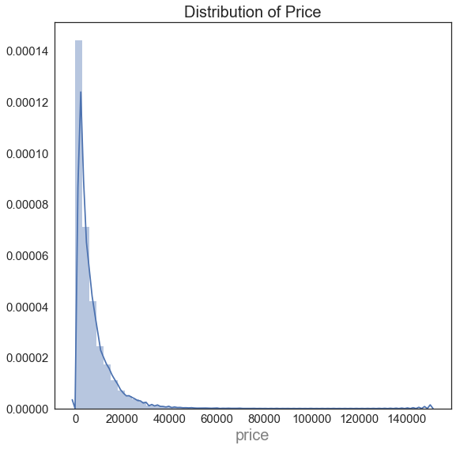

```python
# distribution of price
plt.subplots(figsize=(9, 9))
plt.title('Distribution of Price', fontsize=20)
plt.xlabel('$Price$', fontsize=20, color='gray')
plt.xticks(fontsize=15)
plt.yticks(fontsize=15)
sns.distplot(df['price'])
```

According to the price distribution plot, we can tell that most of used cars in the market are under 20000, this makes sense since people tend to buy new cars if the they have more than 20000 in the pocket.

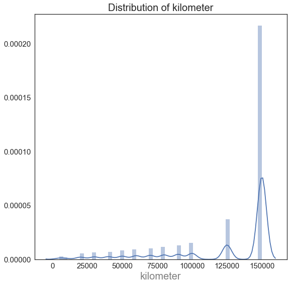

```python
# distribution of kilometer
plt.subplots(figsize=(9, 9))
plt.title('Distribution of kilometer', fontsize=20)
plt.xlabel('$kilometer$', fontsize=20, color='gray')
plt.xticks(fontsize=15)
plt.yticks(fontsize=15)
sns.distplot(df['kilometer'])
```

According to the kilometer distribution plot,it seems that most used cars's mileages are around 150000 kilometers.There are a few people sell their cars when the mileages are under 50000 kilometers.

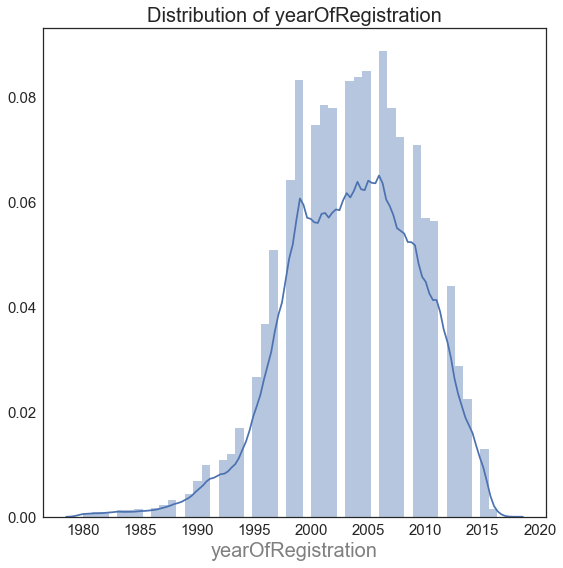

```python
# distribution of year
plt.subplots(figsize=(9, 9))
plt.title('Distribution of yearOfRegistration', fontsize=20)
plt.xlabel('$yearOfRegistration$', fontsize=20, color='gray')
plt.xticks(fontsize=15)
plt.yticks(fontsize=15)
sns.distplot(df['yearOfRegistration'])
```

According to the yearOfRegistration distribution plot,most used cars register between 1995s and 2015s. Most people will not choice a used car that has been registered for over 20 years!

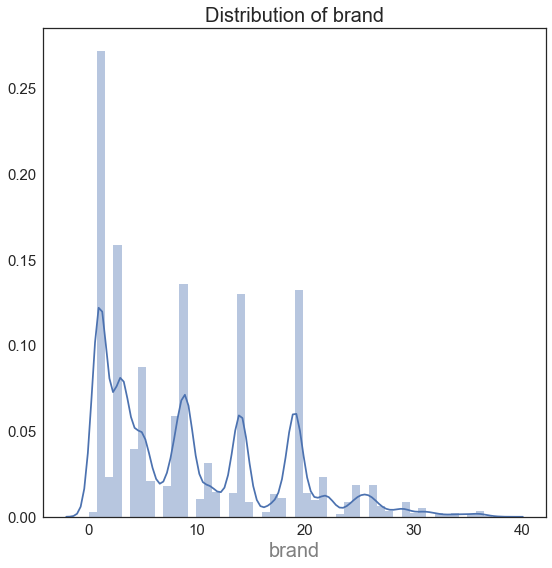

```python
# distribution of brand
plt.subplots(figsize=(9, 9))
plt.title('Distribution of brand', fontsize=20)
plt.xlabel('$brand$', fontsize=20, color='gray')
plt.xticks(fontsize=15)
plt.yticks(fontsize=15)
sns.distplot(ddf['brand'])
```

```python
branddic
```

```
{'alfa_romeo': 15,
 'audi': 14,
 'bmw': 3,
 'chevrolet': 27,
 'chrysler': 31,
 'citroen': 25,
 'dacia': 28,
 'daewoo': 35,
 'daihatsu': 30,
 'fiat': 11,
 'ford': 5,
 'honda': 10,
 'hyundai': 20,
 'jaguar': 32,
 'jeep': 0,
 'kia': 21,
 'lada': 37,
 'lancia': 23,
 'land_rover': 36,
 'mazda': 6,
 'mercedes_benz': 9,
 'mini': 12,
 'mitsubishi': 18,
 'nissan': 7,
 'opel': 19,
 'peugeot': 4,
 'porsche': 24,
 'renault': 8,
 'rover': 33,
 'saab': 34,
 'seat': 22,
 'skoda': 2,
 'smart': 13,
 'subaru': 16,
 'suzuki': 29,
 'toyota': 26,
 'trabant': 38,
 'volkswagen': 1,
 'volvo': 17}
```

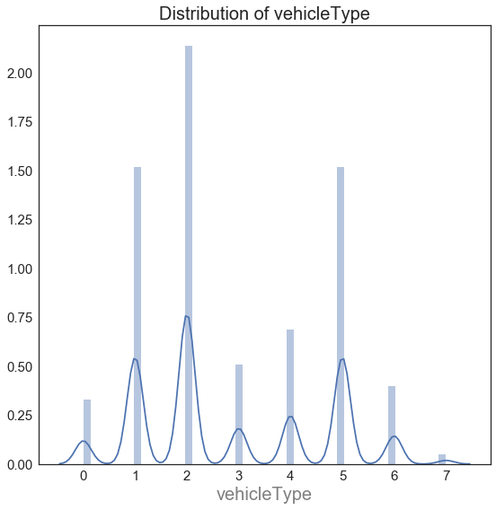

```python
# distribution of vehicleType
plt.subplots(figsize=(9, 9))
plt.title('Distribution of vehicleType', fontsize=20)
plt.xlabel('$vehicleType$', fontsize=20, color='gray')
plt.xticks(fontsize=15)
plt.yticks(fontsize=15)
sns.distplot(ddf['vehicleType'])
```

```python
vtdic
```

```
{'andere': 7,
 'bus': 4,
 'cabrio': 3,
 'coupe': 6,
 'kleinwagen': 1,
 'kombi': 5,
 'limousine': 2,
 'suv': 0}
```

According to the vehicleType distribution plot,most cars which peopel want to trade are limousine cars.We can say that limousine cars are the most popular cars in used car database.

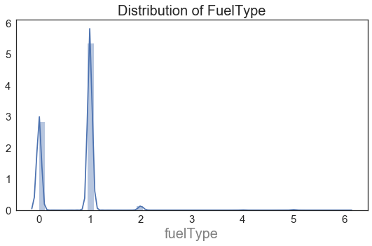

```python
# distribution of fuelType
plt.subplots(figsize=(9, 5))
plt.title('Distribution of FuelType', fontsize=20)
plt.xlabel('$FuelType$', fontsize=20, color='gray')
plt.xticks(fontsize=15)
plt.yticks(fontsize=15)
sns.distplot(ddf['fuelType'])
```

```python
fueldic
```

```
{'andere': 3,
 'benzin': 1,
 'cng': 5,
 'diesel': 0,
 'elektro': 6,
 'hybrid': 4,
 'lpg': 2}
```

According to the fuelType distribution plot,most of used cars' fuel type are (benzin)gasoline and (diesel)diesal.There are rarely used cars use lpg as their fuel.

#### 3.1.1 Price by brand

Let's see the relation between the average price and brand

```python
def label_price (row):
   if row['price'] <= 5000.0:
      return 1
   if (row['price'] > 5000.0) & (row['price'] <= 10000):
      return 2
   if (row['price'] > 10000.0) & (row['price'] <= 15000.0):
      return 3
   if (row['price'] > 15000.0) & (row['price'] <= 20000.0):
      return 4
   if (row['price'] > 20000.0) & (row['price'] <= 25000.0):
      return 5
   if (row['price'] > 25000.0) & (row['price'] <= 30000.0):
      return 6
   if (row['price'] > 30000.0) & (row['price'] <= 35000.0):
      return 7
   if (row['price'] > 35000.0) & (row['price'] <= 40000.0):
      return 8
   if (row['price'] > 40000.0):
      return 9
   return 0
df['price_grp'] = df.apply (lambda row: label_price (row),axis=1)
```

```python
df.head()
```

|  | name | price | vehicleType | yearOfRegistration | gearbox | powerPS | model | kilometer | fuelType | brand | notRepairedDamage | postalCode | price_grp |
| --- | --- | --- | --- | --- | --- | --- | --- | --- | --- | --- | --- | --- | --- |
| 2 | Jeep_Grand_Cherokee_"Overland" | 9800 | suv | 2004 | automatik | 163 | grand | 125000 | diesel | jeep | True | 90480 | 2 |
| 3 | GOLF_4_1_4__3TÜRER | 1500 | kleinwagen | 2001 | manuell | 75 | golf | 150000 | benzin | volkswagen | False | 91074 | 1 |
| 4 | Skoda_Fabia_1.4_TDI_PD_Classic | 3600 | kleinwagen | 2008 | manuell | 69 | fabia | 90000 | diesel | skoda | False | 60437 | 1 |
| 5 | BMW_316i___e36_Limousine___Bastlerfahrzeug__Ex... | 650 | limousine | 1995 | manuell | 102 | 3er | 150000 | benzin | bmw | True | 33775 | 1 |
| 6 | Peugeot_206_CC_110_Platinum | 2200 | cabrio | 2004 | manuell | 109 | 2_reihe | 150000 | benzin | peugeot | False | 67112 | 1 |

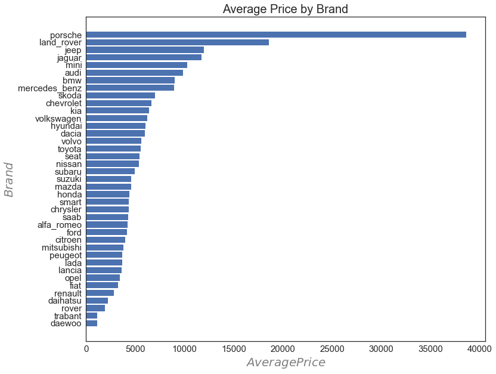

```python
df_groupby_brand = df.groupby(by=['brand'])['price'].mean().sort_values()
a = df['brand'].unique()
r = range(len(a))

plt.figure(figsize=(12,10))
plt.barh(r, df_groupby_brand)
plt.xticks(fontsize=15)
plt.yticks(r, df_groupby_brand.index, fontsize=15)
plt.title('Average Price by Brand', fontsize=20)
plt.xlabel('$Average Price$', fontsize=20, color='gray')
plt.ylabel('$Brand$', fontsize=20, color='gray')
plt.show()
```

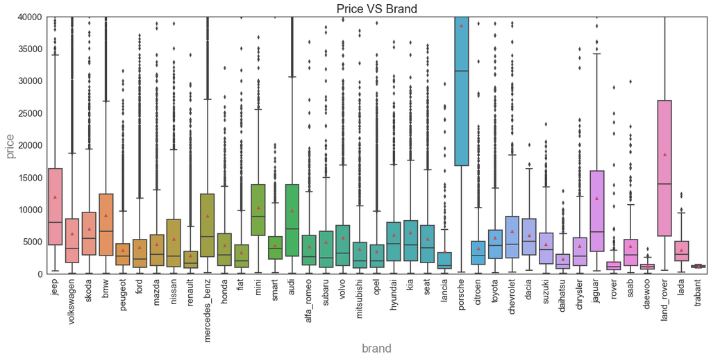

```python
plt.figure(figsize=(20, 8))
plt.xticks(fontsize=15,rotation=90)
plt.yticks(fontsize=15)
plt.ylim((0, 40000))
plt.title('Price VS Brand', fontsize=20)
plt.xlabel('$brand$', fontsize=20, color='gray')
plt.ylabel('$price$', fontsize=20, color='gray')
sns.boxplot(x='brand', y='price', data=df, sym='r*', meanline=False, showmeans=True)
```

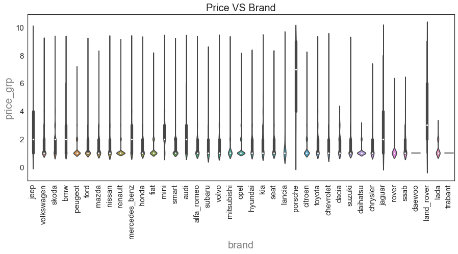

```python
plt.figure(figsize=(15, 6))
plt.xticks(fontsize=15,rotation=90)
plt.yticks(fontsize=15)
#plt.ylim((0, 50000))
plt.title('Price VS Brand', fontsize=20)
plt.xlabel('$brand$', fontsize=20, color='gray')
plt.ylabel('$price$', fontsize=20, color='gray')
sns.violinplot(x='brand',y='price_grp',data=df)
```

It seems that the cars of Porsche have the highest average price and most widely range of price.The average price of Porsche's used cars can reach to 35000 dollars But if you don't have enough money,there are also lots of brands you can choice like daewoo,trabant and other brands.

#### 3.1.2 Price by vehicleType

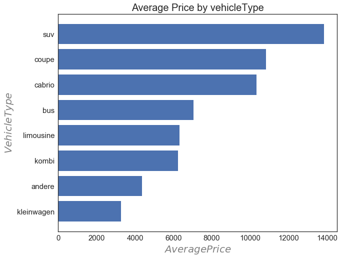

```python
df_groupby_vehicleType = df.groupby(by=['vehicleType'])['price'].mean().sort_values()
r = range(len(df['vehicleType'].unique()))

plt.figure(figsize=(10, 8))
plt.barh(r, df_groupby_vehicleType)
plt.xticks(fontsize=15)
plt.yticks(r, df_groupby_vehicleType.index, fontsize=15)
plt.title('Average Price by vehicleType', fontsize=20)
plt.xlabel('$Average Price$', fontsize=20, color='gray')
plt.ylabel('$VehicleType$', fontsize=20, color='gray')
plt.show()
```

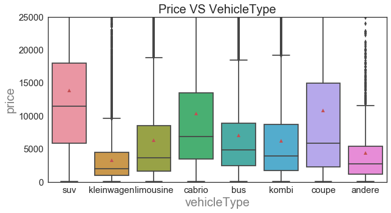

```python
plt.figure(figsize=(10, 5))
plt.xticks(fontsize=15)
plt.yticks(fontsize=15)
plt.ylim((0, 25000))
plt.title('Price VS VehicleType', fontsize=20)
plt.xlabel('$VehicleType$', fontsize=20, color='gray')
plt.ylabel('$Price$', fontsize=20, color='gray')
sns.boxplot(x='vehicleType', y='price', data=df, sym='r*', meanline=False, showmeans=True)
```

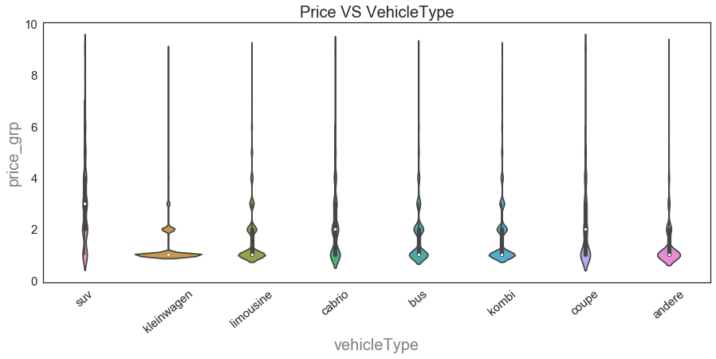

```python
plt.figure(figsize=(15, 6))
plt.xticks(fontsize=15,rotation=40)
plt.yticks(fontsize=15)
#plt.ylim((0, 50000))
plt.title('Price VS VehicleType', fontsize=20)
plt.xlabel('$VehicleType$', fontsize=20, color='gray')
plt.ylabel('$Price$', fontsize=20, color='gray')
sns.violinplot(x='vehicleType',y='price_grp',data=df)
```

#### 3.1.3 Price by gearbox

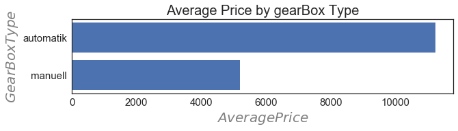

```python
df_groupby_gearbox = df.groupby(by=['gearbox'])['price'].mean().sort_values()
r = range(len(df['gearbox'].unique()))

plt.figure(figsize=(10, 2))
plt.barh(r, df_groupby_gearbox)
plt.xticks(fontsize=15)
plt.yticks(r, df_groupby_gearbox.index, fontsize=15)
plt.title('Average Price by gearBox Type', fontsize=20)
plt.xlabel('$Average Price$', fontsize=20, color='gray')
plt.ylabel('$GearBox Type$', fontsize=20, color='gray')
plt.show()
```

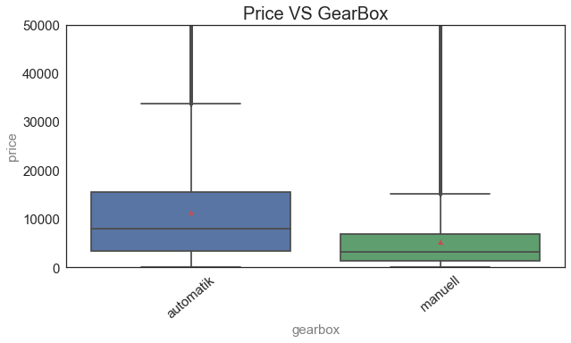

```python
plt.figure(figsize=(10, 5))
plt.xticks(fontsize=15,rotation=40)
plt.yticks(fontsize=15)
plt.ylim((0, 50000))
plt.title('Price VS GearBox', fontsize=20)
plt.xlabel('$gearbox$', fontsize=15, color='gray')
plt.ylabel('$Price$', fontsize=15, color='gray')
sns.boxplot(x='gearbox', y='price', data=df, sym='r*', meanline=False, showmeans=True)
```

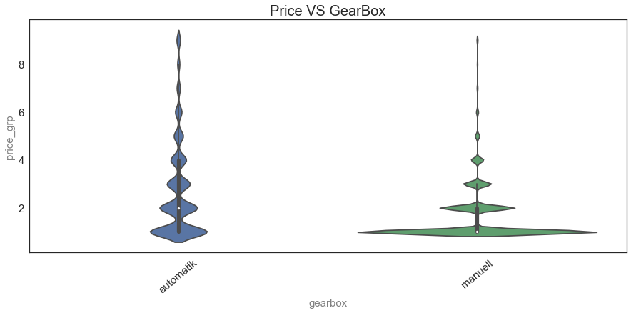

```python
plt.figure(figsize=(15, 6))
plt.xticks(fontsize=15,rotation=40)
plt.yticks(fontsize=15)
#plt.ylim((0, 50000))
plt.title('Price VS GearBox', fontsize=20)
plt.xlabel('$gearbox$', fontsize=15, color='gray')
plt.ylabel('$Price$', fontsize=15, color='gray')
sns.violinplot(x='gearbox',y='price_grp',data=df)
```

We can see from the relation between gearbox and price that the average price of automatic cars is higher than manuell cars. But we highly recommend you to buy automatic cars because vehicles equipped with automatic gearbox are not as complex to drive except unless you are a crazy fan of manuell cars.

#### 3.1.4 Price by fuelType

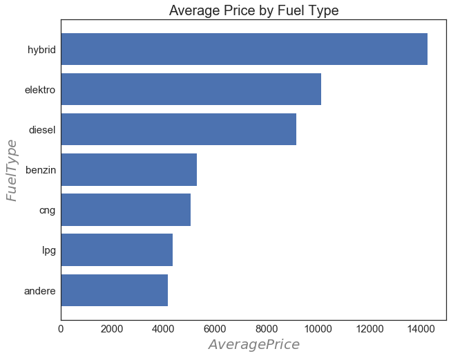

```python
df_groupby_fuelType = df.groupby(by=['fuelType'])['price'].mean().sort_values()
r = range(len(df['fuelType'].unique()))

plt.figure(figsize=(10, 8))
plt.barh(r, df_groupby_fuelType)
plt.xticks(fontsize=15)
plt.yticks(r, df_groupby_fuelType.index, fontsize=15)
plt.title('Average Price by Fuel Type', fontsize=20)
plt.xlabel('$Average Price$', fontsize=20, color='gray')
plt.ylabel('$Fuel Type$', fontsize=20, color='gray')
plt.show()
```

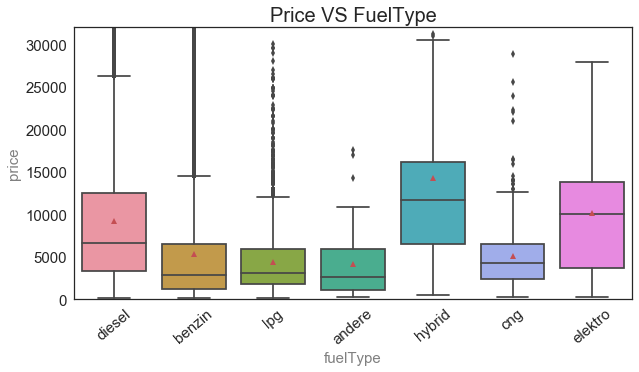

```python
plt.figure(figsize=(10, 5))
plt.xticks(fontsize=15,rotation=40)
plt.yticks(fontsize=15)
plt.ylim((0, 32000))
plt.title('Price VS FuelType', fontsize=20)
plt.xlabel('$fuelType$', fontsize=15, color='gray')
plt.ylabel('$Price$', fontsize=15, color='gray')
sns.boxplot(x='fuelType', y='price', data=df, sym='r*', meanline=False, showmeans=True)
```

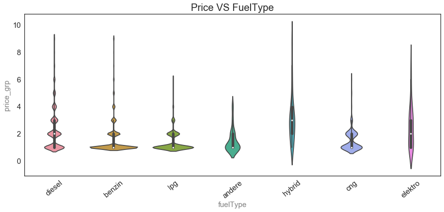

```python
plt.figure(figsize=(15, 6))
plt.xticks(fontsize=15,rotation=40)
plt.yticks(fontsize=15)
#plt.ylim((0, 50000))
plt.title('Price VS FuelType', fontsize=20)
plt.xlabel('$fuelType$', fontsize=15, color='gray')
plt.ylabel('$Price$', fontsize=15, color='gray')
sns.violinplot(x='fuelType',y='price_grp',data=df)
```

It seems that the average price of hybird and elektro(electrical) cars is higher than cars which fueltype is benzin(gasoline) or diesel. Because of advanced technology which is within hybrids, they may cost an extra dozen or $2000 or more over the conventional gasoline powered equivalent. The main reason for the difference in price besides the advanced technology is the cost of the batteries.

#### 3.1.5 Price by notRepairedDamage

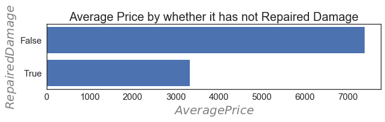

```python
df_groupby_nRD = df.groupby(by=['notRepairedDamage'])['price'].mean().sort_values()
r = range(len(df['notRepairedDamage'].unique()))

plt.figure(figsize=(10, 2))
plt.barh(r, df_groupby_nRD)
plt.xticks(fontsize=15)
plt.yticks(r, df_groupby_nRD.index, fontsize=15)
plt.title('Average Price by whether it has not Repaired Damage', fontsize=20)
plt.xlabel('$Average Price$', fontsize=20, color='gray')
plt.ylabel('$Repaired Damage$', fontsize=20, color='gray')
plt.show()
```

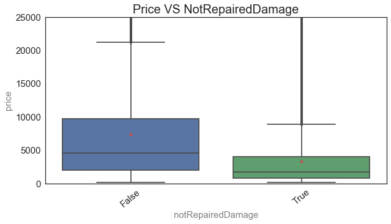

```python
plt.figure(figsize=(10, 5))
plt.xticks(fontsize=15,rotation=40)
plt.yticks(fontsize=15)
plt.ylim((0, 25000))
plt.title('Price VS NotRepairedDamage', fontsize=20)
plt.xlabel('$notRepairedDamage$', fontsize=15, color='gray')
plt.ylabel('$Price$', fontsize=15, color='gray')
sns.boxplot(x='notRepairedDamage', y='price', data=df, sym='r*', meanline=False, showmeans=True)
```

We all know that the repaired damage can devalue the price of cars and these charts prove our thoughts.There are a few people want to buy a used cars which are under repaired damage except they have limit budget

#### 3.1.6 Price by Kilometer

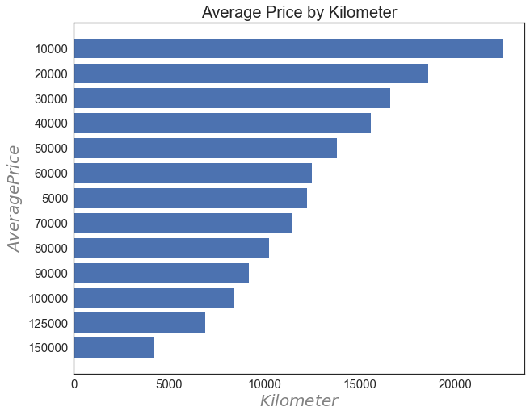

```python
df_groupby_kilometer = df.groupby(by=['kilometer'])['price'].mean().sort_values()
r = range(len(df['kilometer'].unique()))

plt.figure(figsize=(10, 8))
plt.barh(r, df_groupby_kilometer)
plt.xticks(fontsize=15)
plt.yticks(r, df_groupby_kilometer.index, fontsize=15)
plt.title('Average Price by Kilometer', fontsize=20)
plt.xlabel('$Kilometer$', fontsize=20, color='gray')
plt.ylabel('$Average Price$', fontsize=20, color='gray')
plt.show()
```

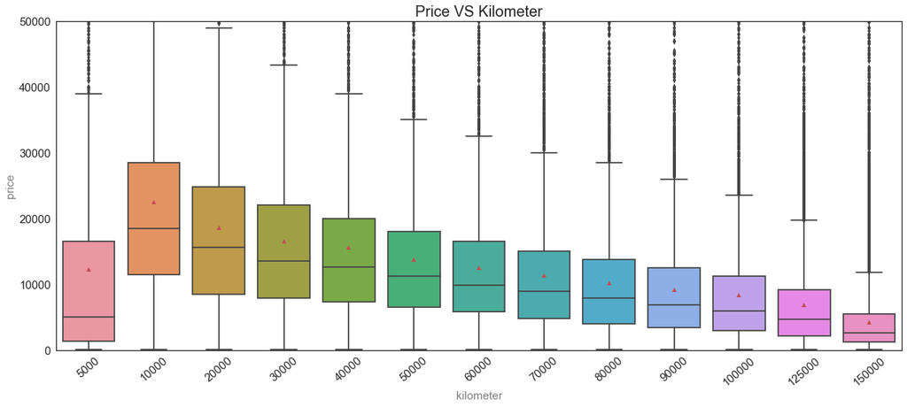

```python
plt.figure(figsize=(20, 8))
plt.xticks(fontsize=15,rotation=40)
plt.yticks(fontsize=15)
plt.ylim((0, 50000))
plt.title('Price VS Kilometer', fontsize=20)
plt.xlabel('$kilometer$', fontsize=15, color='gray')
plt.ylabel('$Price$', fontsize=15, color='gray')
sns.boxplot(x='kilometer', y='price', data=df, sym='r*', meanline=False, showmeans=True)
```

```python
p=min(df['price'])
q=max(df['price'])
print(q)
```

```
150000
```

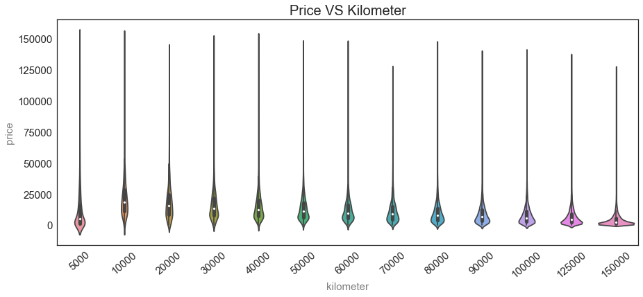

```python
plt.figure(figsize=(15, 6))
plt.xticks(fontsize=15,rotation=40)
plt.yticks(fontsize=15)
#plt.ylim((0, 50000))
plt.title('Price VS Kilometer', fontsize=20)
plt.xlabel('$kilometer$', fontsize=15, color='gray')
plt.ylabel('$Price$', fontsize=15, color='gray')
sns.violinplot(x='kilometer',y='price',data=df)
```

Distribution of Price VS Kilometer suggests that the average price will fall along with the increase in kilometers but the price of cars which mileage less than 5000 is obviously different from other datas.

#### Why 5000 is abnormal?

```python
df_groupby_a = df.groupby(by=['kilometer','notRepairedDamage'])
```

```python
print(df_groupby_a['name'].count())
```

```
kilometer  notRepairedDamage
5000       False                  1549
           True                    666
10000      False                  1326
           True                     94
20000      False                  3916
           True                    405
30000      False                  4514
           True                    412
40000      False                  4988
           True                    414
50000      False                  5847
           True                    517
60000      False                  6627
           True                    636
70000      False                  7223
           True                    815
80000      False                  7974
           True                    943
90000      False                  8749
           True                   1246
100000     False                 10394
           True                   1606
125000     False                 24649
           True                   4499
150000     False                129095
           True                  40168
Name: name, dtype: int64
```

According to the graph above ,there are nearly one-third amount of cars which mileage is less than 5000 kilometers have repaired damages.The repaired damage is an important factor to devalue the price of cars. So we assume that the reason for the abnormal graph is that some of repaired damage cars decrease the whole price of cars.

#### 3.1.7 Price by yearOfRegistration

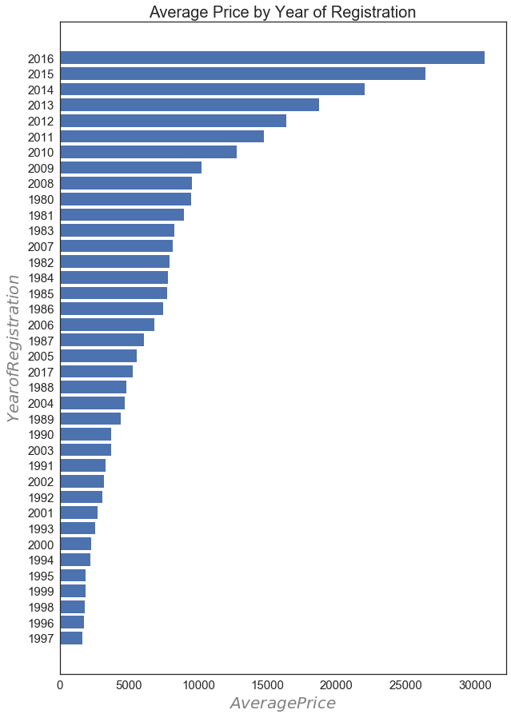

```python
df_groupby_yOR = df.groupby(by=['yearOfRegistration'])['price'].mean().sort_values()
r = range(len(df['yearOfRegistration'].unique()))

plt.figure(figsize=(10, 15))
plt.barh(r, df_groupby_yOR)
plt.xticks(fontsize=15)
plt.yticks(r, df_groupby_yOR.index, fontsize=15)
plt.title('Average Price by Year of Registration', fontsize=20)
plt.xlabel('$Average Price$', fontsize=20, color='gray')
plt.ylabel('$Year of Registration$', fontsize=20, color='gray')
plt.show()
```

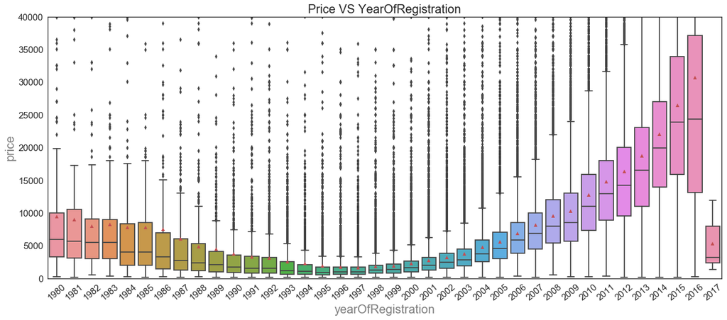

```python
plt.figure(figsize=(20, 8))
plt.xticks(fontsize=15,rotation=40)
plt.yticks(fontsize=15)
plt.ylim((0, 40000))
plt.title('Price VS YearOfRegistration', fontsize=20)
plt.xlabel('$yearOfRegistration$', fontsize=20, color='gray')
plt.ylabel('$Price$', fontsize=20, color='gray')
sns.boxplot(x='yearOfRegistration', y='price', data=df, sym='r*', meanline=False, showmeans=True)
```

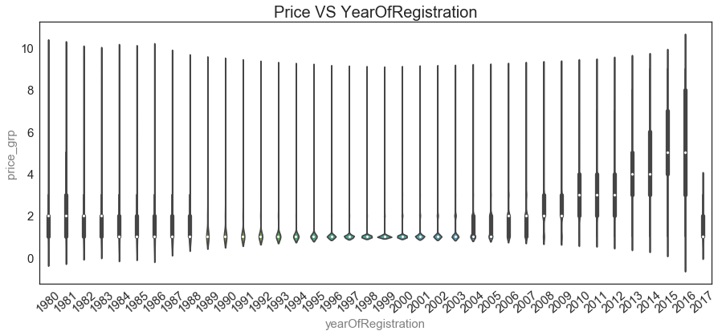

```python
plt.figure(figsize=(15, 6))
plt.xticks(fontsize=15,rotation=40)
plt.yticks(fontsize=15)
#plt.ylim((0, 50000))
plt.title('Price VS YearOfRegistration', fontsize=20)
plt.xlabel('$YearOfRegistration$', fontsize=15, color='gray')
plt.ylabel('$Price$', fontsize=15, color='gray')
sns.violinplot(x='yearOfRegistration',y='price_grp',data=df)
```

Distribution of Price VS YearOfRegistration suggests that the price will increase along with year of registration after 1995s. Some used cars can be sold at a very high price beacuse some cars which year of registration before 1995s can be seen as vintage vehicles.

#### 3.1.8 Price by PowerPS

```python
# df["powerPS"].describe()

df['powerPS_Level'] = pd.cut(df['powerPS'],[50,150,250,350,1e4],
                            labels=['50-150','150-250','250-350',
                                   '>350'])
df['powerPS_Level'].describe()
```

```
count     269272
unique         4
top       50-150
freq      200188
Name: powerPS_Level, dtype: object
```

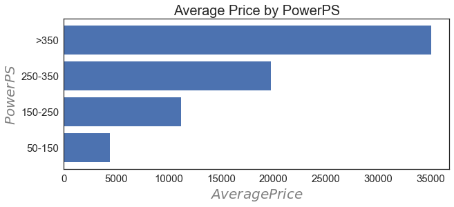

```python
df_groupby_PS = df.groupby(by=['powerPS_Level'])['price'].mean().sort_values()
r = range(len(df['powerPS_Level'].unique()))

plt.figure(figsize=(10, 4))
plt.barh(r, df_groupby_PS)
plt.xticks(fontsize=15)
plt.yticks(r, df_groupby_PS.index, fontsize=15)
plt.title('Average Price by PowerPS', fontsize=20)
plt.xlabel('$Average Price$', fontsize=20, color='gray')
plt.ylabel('$PowerPS$', fontsize=20, color='gray')
plt.show()
```

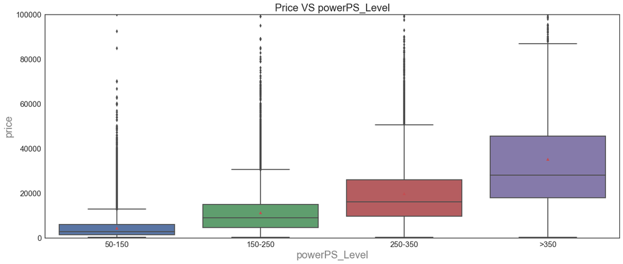

```python
plt.figure(figsize=(20, 8))
plt.xticks(fontsize=15)
plt.yticks(fontsize=15)
plt.ylim((0, 100000))
plt.title('Price VS powerPS_Level', fontsize=20)
plt.xlabel('$powerPS_Level$', fontsize=20, color='gray')
plt.ylabel('$Price$', fontsize=20, color='gray')
sns.boxplot(x='powerPS_Level', y='price', data=df, sym='r*', meanline=False, showmeans=True)
```

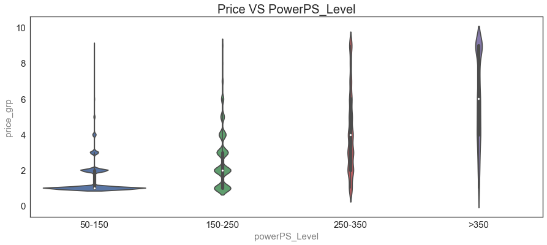

```python
plt.figure(figsize=(15, 6))
plt.xticks(fontsize=15)
plt.yticks(fontsize=15)
#plt.ylim((0, 50000))
plt.title('Price VS PowerPS_Level', fontsize=20)
plt.xlabel('$powerPS_Level$', fontsize=15, color='gray')
plt.ylabel('$Price$', fontsize=15, color='gray')
sns.violinplot(x='powerPS_Level',y='price_grp',data=df)
```

```python
df.drop(['powerPS_Level'],axis=1,inplace=True)
```

It is obvious from these graphs that the price will go higher with the increase powerPS_Level and the increase ratio is not linear.To increase powerPS_level,you need to do lots of things like changing air filter,adding cold-air intake system and adding performance headers. These will cost a lot.So it make sense that increase ratio between price and powerPS_level is not linear.